# Optimal Treatment Analysis

## Outcome Variable

**Outcome Variable:** haz

## Predictor Variables

**Intervention Variable:** hhwealth_quart

**Adjustment Set:**

- arm
- sex
- W_mage
- meducyrs
- feducyrs
- W_gagebrth
- W_birthwt
- W_birthlen
- W_nchldlt5
- W_parity
- delta_W_mage
- delta_meducyrs
- delta_feducyrs
- delta_W_gagebrth
- delta_W_birthwt
- delta_W_birthlen
- delta_W_nchldlt5
- delta_W_parity

## Stratifying Variables

The analysis was stratified on these variable(s):

- agecat
- studyid
- country

## Data Summary

| agecat | studyid | country | hhwealth_quart | n_cell | n |
| --- | --- | --- | --- | --- | --- |
| Birth | CMC-V-BCS-2002 | INDIA | Wealth Q4 | 32 | 92 |
| Birth | CMC-V-BCS-2002 | INDIA | Wealth Q1 | 15 | 92 |
| Birth | CMC-V-BCS-2002 | INDIA | Wealth Q2 | 20 | 92 |
| Birth | CMC-V-BCS-2002 | INDIA | Wealth Q3 | 25 | 92 |
| Birth | COHORTS | GUATEMALA | Wealth Q4 | 293 | 816 |
| Birth | COHORTS | GUATEMALA | Wealth Q1 | 157 | 816 |
| Birth | COHORTS | GUATEMALA | Wealth Q2 | 161 | 816 |
| Birth | COHORTS | GUATEMALA | Wealth Q3 | 205 | 816 |
| Birth | COHORTS | PHILIPPINES | Wealth Q4 | 842 | 3049 |
| Birth | COHORTS | PHILIPPINES | Wealth Q1 | 687 | 3049 |
| Birth | COHORTS | PHILIPPINES | Wealth Q2 | 538 | 3049 |
| Birth | COHORTS | PHILIPPINES | Wealth Q3 | 982 | 3049 |
| Birth | CONTENT | PERU | Wealth Q4 | 0 | 2 |
| Birth | CONTENT | PERU | Wealth Q1 | 0 | 2 |
| Birth | CONTENT | PERU | Wealth Q2 | 1 | 2 |
| Birth | CONTENT | PERU | Wealth Q3 | 1 | 2 |
| Birth | GMS-Nepal | NEPAL | Wealth Q4 | 173 | 696 |
| Birth | GMS-Nepal | NEPAL | Wealth Q1 | 175 | 696 |
| Birth | GMS-Nepal | NEPAL | Wealth Q2 | 174 | 696 |
| Birth | GMS-Nepal | NEPAL | Wealth Q3 | 174 | 696 |
| Birth | IRC | INDIA | Wealth Q4 | 91 | 388 |
| Birth | IRC | INDIA | Wealth Q1 | 98 | 388 |
| Birth | IRC | INDIA | Wealth Q2 | 99 | 388 |
| Birth | IRC | INDIA | Wealth Q3 | 100 | 388 |
| Birth | JiVitA-3 | BANGLADESH | Wealth Q4 | 5278 | 22434 |
| Birth | JiVitA-3 | BANGLADESH | Wealth Q1 | 5772 | 22434 |
| Birth | JiVitA-3 | BANGLADESH | Wealth Q2 | 5701 | 22434 |
| Birth | JiVitA-3 | BANGLADESH | Wealth Q3 | 5683 | 22434 |
| Birth | JiVitA-4 | BANGLADESH | Wealth Q4 | 654 | 2820 |
| Birth | JiVitA-4 | BANGLADESH | Wealth Q1 | 685 | 2820 |

[output cut: 178 more lines]

The following strata were considered:

- agecat: 24 months, studyid: CMC-V-BCS-2002, country: INDIA
- agecat: 24 months, studyid: COHORTS, country: GUATEMALA
- agecat: 24 months, studyid: COHORTS, country: PHILIPPINES
- agecat: 24 months, studyid: CONTENT, country: PERU
- agecat: 24 months, studyid: GMS-Nepal, country: NEPAL
- agecat: 24 months, studyid: IRC, country: INDIA
- agecat: 24 months, studyid: JiVitA-3, country: BANGLADESH
- agecat: 24 months, studyid: JiVitA-4, country: BANGLADESH
- agecat: 24 months, studyid: LCNI-5, country: MALAWI
- agecat: 24 months, studyid: MAL-ED, country: BANGLADESH
- agecat: 24 months, studyid: MAL-ED, country: BRAZIL
- agecat: 24 months, studyid: MAL-ED, country: INDIA
- agecat: 24 months, studyid: MAL-ED, country: NEPAL
- agecat: 24 months, studyid: MAL-ED, country: PERU
- agecat: 24 months, studyid: MAL-ED, country: SOUTH AFRICA
- agecat: 24 months, studyid: MAL-ED, country: TANZANIA, UNITED REPUBLIC OF
- agecat: 24 months, studyid: PROVIDE, country: BANGLADESH
- agecat: 24 months, studyid: TanzaniaChild2, country: TANZANIA, UNITED REPUBLIC OF
- agecat: 6 months, studyid: CMC-V-BCS-2002, country: INDIA
- agecat: 6 months, studyid: COHORTS, country: GUATEMALA
- agecat: 6 months, studyid: COHORTS, country: PHILIPPINES
- agecat: 6 months, studyid: CONTENT, country: PERU
- agecat: 6 months, studyid: GMS-Nepal, country: NEPAL
- agecat: 6 months, studyid: IRC, country: INDIA
- agecat: 6 months, studyid: JiVitA-3, country: BANGLADESH
- agecat: 6 months, studyid: JiVitA-4, country: BANGLADESH
- agecat: 6 months, studyid: LCNI-5, country: MALAWI
- agecat: 6 months, studyid: MAL-ED, country: BANGLADESH
- agecat: 6 months, studyid: MAL-ED, country: BRAZIL
- agecat: 6 months, studyid: MAL-ED, country: INDIA
- agecat: 6 months, studyid: MAL-ED, country: NEPAL
- agecat: 6 months, studyid: MAL-ED, country: PERU
- agecat: 6 months, studyid: MAL-ED, country: SOUTH AFRICA
- agecat: 6 months, studyid: MAL-ED, country: TANZANIA, UNITED REPUBLIC OF
- agecat: 6 months, studyid: PROVIDE, country: BANGLADESH
- agecat: 6 months, studyid: TanzaniaChild2, country: TANZANIA, UNITED REPUBLIC OF
- agecat: Birth, studyid: CMC-V-BCS-2002, country: INDIA
- agecat: Birth, studyid: COHORTS, country: GUATEMALA
- agecat: Birth, studyid: COHORTS, country: PHILIPPINES
- agecat: Birth, studyid: CONTENT, country: PERU
- agecat: Birth, studyid: GMS-Nepal, country: NEPAL
- agecat: Birth, studyid: IRC, country: INDIA
- agecat: Birth, studyid: JiVitA-3, country: BANGLADESH
- agecat: Birth, studyid: JiVitA-4, country: BANGLADESH
- agecat: Birth, studyid: MAL-ED, country: BANGLADESH
- agecat: Birth, studyid: MAL-ED, country: BRAZIL
- agecat: Birth, studyid: MAL-ED, country: INDIA
- agecat: Birth, studyid: MAL-ED, country: NEPAL
- agecat: Birth, studyid: MAL-ED, country: PERU
- agecat: Birth, studyid: MAL-ED, country: SOUTH AFRICA
- agecat: Birth, studyid: MAL-ED, country: TANZANIA, UNITED REPUBLIC OF
- agecat: Birth, studyid: PROVIDE, country: BANGLADESH

### Dropped Strata

Some strata were dropped due to rare outcomes:

## Methods Detail

We’re interested in the causal parameters $E[Y_a]$ for all values of $a \in \mathcal{A}$. These parameters represent the mean outcome if, possibly contrary to fact, we intervened to set all units to have $A=a$. Under the randomization and positivity assumptions, these are identified by the statistical parameters $\psi_a=E_W[E_{Y|A,W}(Y|A=a,W)]$. In addition, we’re interested in the mean of $Y$, $E[Y]$ under no intervention (the observed mean). We will estimate these parameters by using SuperLearner to fit the relevant likelihood factors – $E_{Y|A,W}(Y|A=a,W)$ and $p(A=a|W)$, and then updating our likelihood fit using a joint TMLE.

For unadjusted analyses ($W=\{\}$), initial likelihoods were estimated using Lrnr_glm to estimate the simple $E(Y|A)$ and Lrnr_mean to estimate $p(A)$. For adjusted analyses, a small library containing Lrnr_glmnet, Lrnr_xgboost, and Lrnr_mean was used.

Having estimated these parameters, we will then use the delta method to estimate relative risks and attributable risks relative to a prespecified baseline level of $A$.

[output not shown]

# Results Detail

## Results Plots

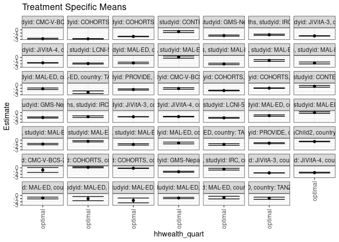

## Results Table

### Parameter: TSM

| agecat | studyid | country | intervention_level | baseline_level | estimate | ci_lower | ci_upper |
| --- | --- | --- | --- | --- | --- | --- | --- |
| Birth | CMC-V-BCS-2002 | INDIA | optimal | observed | -0.6872939 | -1.4499156 | 0.0753279 |
| Birth | COHORTS | GUATEMALA | optimal | observed | 0.1592233 | -0.0001248 | 0.3185714 |
| Birth | COHORTS | PHILIPPINES | optimal | observed | -0.1385354 | -0.2090654 | -0.0680055 |
| Birth | GMS-Nepal | NEPAL | optimal | observed | -1.2148410 | -1.3715946 | -1.0580873 |
| Birth | IRC | INDIA | optimal | observed | -0.4216926 | -0.7053948 | -0.1379905 |
| Birth | JiVitA-3 | BANGLADESH | optimal | observed | -1.5796754 | -1.6238104 | -1.5355405 |
| Birth | JiVitA-4 | BANGLADESH | optimal | observed | -1.5002810 | -1.6269799 | -1.3735822 |
| Birth | MAL-ED | BANGLADESH | optimal | observed | -0.8059304 | -1.0845991 | -0.5272616 |
| Birth | MAL-ED | BRAZIL | optimal | observed | -0.9960370 | -1.6368506 | -0.3552235 |
| Birth | MAL-ED | INDIA | optimal | observed | -1.5605608 | -2.3207272 | -0.8003945 |
| Birth | MAL-ED | PERU | optimal | observed | -0.8003923 | -0.9981373 | -0.6026473 |
| Birth | MAL-ED | SOUTH AFRICA | optimal | observed | -0.6839363 | -1.0888026 | -0.2790700 |
| Birth | MAL-ED | TANZANIA, UNITED REPUBLIC OF | optimal | observed | -0.8864704 | -1.2294797 | -0.5434611 |
| 6 months | CMC-V-BCS-2002 | INDIA | optimal | observed | -1.0881666 | -1.3378389 | -0.8384943 |
| 6 months | COHORTS | GUATEMALA | optimal | observed | -1.7032202 | -1.8225777 | -1.5838626 |
| 6 months | COHORTS | PHILIPPINES | optimal | observed | -0.9615325 | -1.0441580 | -0.8789070 |
| 6 months | CONTENT | PERU | optimal | observed | -0.4091421 | -0.6769286 | -0.1413556 |
| 6 months | GMS-Nepal | NEPAL | optimal | observed | -1.5267507 | -1.7015411 | -1.3519603 |
| 6 months | IRC | INDIA | optimal | observed | -1.2598274 | -1.5247920 | -0.9948627 |
| 6 months | JiVitA-3 | BANGLADESH | optimal | observed | -1.2861731 | -1.3394317 | -1.2329145 |
| 6 months | JiVitA-4 | BANGLADESH | optimal | observed | -1.2411056 | -1.3322735 | -1.1499377 |
| 6 months | LCNI-5 | MALAWI | optimal | observed | -1.6172195 | -1.7576315 | -1.4768075 |
| 6 months | MAL-ED | BANGLADESH | optimal | observed | -0.9282717 | -1.1515629 | -0.7049806 |
| 6 months | MAL-ED | BRAZIL | optimal | observed | 0.0331917 | -0.2221896 | 0.2885730 |
| 6 months | MAL-ED | INDIA | optimal | observed | -1.2040743 | -1.4137542 | -0.9943944 |
| 6 months | MAL-ED | NEPAL | optimal | observed | -0.3516043 | -0.5437710 | -0.1594376 |
| 6 months | MAL-ED | PERU | optimal | observed | -1.3150213 | -1.5273692 | -1.1026734 |
| 6 months | MAL-ED | SOUTH AFRICA | optimal | observed | -0.8604779 | -1.1502081 | -0.5707476 |
| 6 months | MAL-ED | TANZANIA, UNITED REPUBLIC OF | optimal | observed | -1.3082472 | -1.5703380 | -1.0461563 |
| 6 months | PROVIDE | BANGLADESH | optimal | observed | -0.9160038 | -1.0724049 | -0.7596028 |
| 6 months | TanzaniaChild2 | TANZANIA, UNITED REPUBLIC OF | optimal | observed | -0.4144156 | -0.5005984 | -0.3282327 |
| 24 months | CMC-V-BCS-2002 | INDIA | optimal | observed | -2.7783575 | -2.9483035 | -2.6084115 |
| 24 months | COHORTS | GUATEMALA | optimal | observed | -2.8263253 | -2.9286534 | -2.7239972 |
| 24 months | COHORTS | PHILIPPINES | optimal | observed | -2.0575492 | -2.1407733 | -1.9743252 |
| 24 months | CONTENT | PERU | optimal | observed | -0.5462744 | -0.8428820 | -0.2496668 |
| 24 months | GMS-Nepal | NEPAL | optimal | observed | -1.7858813 | -1.9622890 | -1.6094736 |
| 24 months | IRC | INDIA | optimal | observed | -1.5334001 | -1.7237700 | -1.3430302 |
| 24 months | JiVitA-3 | BANGLADESH | optimal | observed | -1.8887288 | -1.9520400 | -1.8254175 |
| 24 months | JiVitA-4 | BANGLADESH | optimal | observed | -1.6798379 | -1.7536451 | -1.6060307 |
| 24 months | LCNI-5 | MALAWI | optimal | observed | -1.8987651 | -2.0621083 | -1.7354219 |
| 24 months | MAL-ED | BANGLADESH | optimal | observed | -1.7156061 | -1.9531087 | -1.4781036 |
| 24 months | MAL-ED | BRAZIL | optimal | observed | 0.0994233 | -0.2371350 | 0.4359816 |
| 24 months | MAL-ED | INDIA | optimal | observed | -2.0288141 | -2.2569627 | -1.8006655 |
| 24 months | MAL-ED | NEPAL | optimal | observed | -0.9428780 | -1.2076607 | -0.6780953 |
| 24 months | MAL-ED | PERU | optimal | observed | -1.7168631 | -2.0134960 | -1.4202302 |
| 24 months | MAL-ED | SOUTH AFRICA | optimal | observed | -1.1592815 | -1.3976789 | -0.9208842 |
| 24 months | MAL-ED | TANZANIA, UNITED REPUBLIC OF | optimal | observed | -2.2518037 | -2.6683564 | -1.8352509 |
| 24 months | PROVIDE | BANGLADESH | optimal | observed | -1.3962871 | -1.5763301 | -1.2162441 |

### Parameter: E(Y)

| agecat | studyid | country | intervention_level | baseline_level | estimate | ci_lower | ci_upper |
| --- | --- | --- | --- | --- | --- | --- | --- |
| Birth | CMC-V-BCS-2002 | INDIA | observed | observed | -0.9611957 | -1.1776967 | -0.7446946 |
| Birth | COHORTS | GUATEMALA | observed | observed | 0.1452941 | 0.0610109 | 0.2295774 |
| Birth | COHORTS | PHILIPPINES | observed | observed | -0.2491505 | -0.2881717 | -0.2101294 |
| Birth | GMS-Nepal | NEPAL | observed | observed | -1.0851580 | -1.1651811 | -1.0051350 |
| Birth | IRC | INDIA | observed | observed | -0.3080412 | -0.4687931 | -0.1472894 |
| Birth | JiVitA-3 | BANGLADESH | observed | observed | -1.5897094 | -1.6089856 | -1.5704331 |
| Birth | JiVitA-4 | BANGLADESH | observed | observed | -1.5236135 | -1.5727559 | -1.4744711 |
| Birth | MAL-ED | BANGLADESH | observed | observed | -1.0530516 | -1.1896058 | -0.9164975 |
| Birth | MAL-ED | BRAZIL | observed | observed | -0.6963333 | -0.9881882 | -0.4044785 |
| Birth | MAL-ED | INDIA | observed | observed | -1.2070732 | -1.5254820 | -0.8886644 |
| Birth | MAL-ED | PERU | observed | observed | -0.9141395 | -1.0364098 | -0.7918693 |
| Birth | MAL-ED | SOUTH AFRICA | observed | observed | -0.5523958 | -0.7550074 | -0.3497843 |
| Birth | MAL-ED | TANZANIA, UNITED REPUBLIC OF | observed | observed | -1.1225000 | -1.3335666 | -0.9114334 |
| 6 months | CMC-V-BCS-2002 | INDIA | observed | observed | -1.4234508 | -1.5645974 | -1.2823042 |
| 6 months | COHORTS | GUATEMALA | observed | observed | -1.8112324 | -1.8807284 | -1.7417365 |
| 6 months | COHORTS | PHILIPPINES | observed | observed | -1.1405724 | -1.1824954 | -1.0986493 |
| 6 months | CONTENT | PERU | observed | observed | -0.2785256 | -0.4098735 | -0.1471776 |
| 6 months | GMS-Nepal | NEPAL | observed | observed | -1.3508392 | -1.4290633 | -1.2726152 |
| 6 months | IRC | INDIA | observed | observed | -1.2344062 | -1.3658524 | -1.1029600 |
| 6 months | JiVitA-3 | BANGLADESH | observed | observed | -1.3132090 | -1.3363486 | -1.2900693 |
| 6 months | JiVitA-4 | BANGLADESH | observed | observed | -1.3440477 | -1.3813060 | -1.3067894 |
| 6 months | LCNI-5 | MALAWI | observed | observed | -1.6426961 | -1.7120603 | -1.5733318 |
| 6 months | MAL-ED | BANGLADESH | observed | observed | -1.2026806 | -1.3203025 | -1.0850586 |
| 6 months | MAL-ED | BRAZIL | observed | observed | 0.0475758 | -0.0963508 | 0.1915023 |
| 6 months | MAL-ED | INDIA | observed | observed | -1.2070638 | -1.3255909 | -1.0885368 |
| 6 months | MAL-ED | NEPAL | observed | observed | -0.5615819 | -0.6741832 | -0.4489807 |
| 6 months | MAL-ED | PERU | observed | observed | -1.3248549 | -1.4336721 | -1.2160378 |
| 6 months | MAL-ED | SOUTH AFRICA | observed | observed | -1.0547925 | -1.1843544 | -0.9252306 |
| 6 months | MAL-ED | TANZANIA, UNITED REPUBLIC OF | observed | observed | -1.3687449 | -1.4907629 | -1.2467270 |
| 6 months | PROVIDE | BANGLADESH | observed | observed | -1.0916915 | -1.1661176 | -1.0172654 |
| 6 months | TanzaniaChild2 | TANZANIA, UNITED REPUBLIC OF | observed | observed | -0.5442232 | -0.5932373 | -0.4952090 |
| 24 months | CMC-V-BCS-2002 | INDIA | observed | observed | -2.5588679 | -2.6583730 | -2.4593629 |
| 24 months | COHORTS | GUATEMALA | observed | observed | -2.9893430 | -3.0546993 | -2.9239867 |
| 24 months | COHORTS | PHILIPPINES | observed | observed | -2.4141145 | -2.4590818 | -2.3691473 |
| 24 months | CONTENT | PERU | observed | observed | -0.6868598 | -0.8388476 | -0.5348719 |
| 24 months | GMS-Nepal | NEPAL | observed | observed | -1.8874180 | -1.9728588 | -1.8019773 |
| 24 months | IRC | INDIA | observed | observed | -1.7987775 | -1.8923914 | -1.7051636 |
| 24 months | JiVitA-3 | BANGLADESH | observed | observed | -2.0135591 | -2.0412422 | -1.9858759 |
| 24 months | JiVitA-4 | BANGLADESH | observed | observed | -1.7803708 | -1.8158650 | -1.7448765 |
| 24 months | LCNI-5 | MALAWI | observed | observed | -1.8822648 | -1.9637218 | -1.8008078 |
| 24 months | MAL-ED | BANGLADESH | observed | observed | -1.9783962 | -2.1050210 | -1.8517715 |
| 24 months | MAL-ED | BRAZIL | observed | observed | 0.0061144 | -0.1625850 | 0.1748138 |
| 24 months | MAL-ED | INDIA | observed | observed | -1.8861894 | -2.0110006 | -1.7613783 |
| 24 months | MAL-ED | NEPAL | observed | observed | -1.3075877 | -1.4270718 | -1.1881037 |
| 24 months | MAL-ED | PERU | observed | observed | -1.7524710 | -1.8736426 | -1.6312994 |
| 24 months | MAL-ED | SOUTH AFRICA | observed | observed | -1.6450595 | -1.7797240 | -1.5103950 |
| 24 months | MAL-ED | TANZANIA, UNITED REPUBLIC OF | observed | observed | -2.6455607 | -2.7807256 | -2.5103959 |
| 24 months | PROVIDE | BANGLADESH | observed | observed | -1.6024221 | -1.6857420 | -1.5191023 |

### Parameter: PAR

| agecat | studyid | country | intervention_level | baseline_level | estimate | ci_lower | ci_upper |
| --- | --- | --- | --- | --- | --- | --- | --- |
| Birth | CMC-V-BCS-2002 | INDIA | optimal | observed | -0.2739018 | -0.9357736 | 0.3879700 |
| Birth | COHORTS | GUATEMALA | optimal | observed | -0.0139292 | -0.1431047 | 0.1152463 |
| Birth | COHORTS | PHILIPPINES | optimal | observed | -0.1106151 | -0.1712058 | -0.0500244 |
| Birth | GMS-Nepal | NEPAL | optimal | observed | 0.1296829 | -0.0034045 | 0.2627703 |
| Birth | IRC | INDIA | optimal | observed | 0.1136514 | -0.1225426 | 0.3498454 |
| Birth | JiVitA-3 | BANGLADESH | optimal | observed | -0.0100339 | -0.0493798 | 0.0293119 |
| Birth | JiVitA-4 | BANGLADESH | optimal | observed | -0.0233324 | -0.1369715 | 0.0903066 |
| Birth | MAL-ED | BANGLADESH | optimal | observed | -0.2471213 | -0.4892630 | -0.0049795 |
| Birth | MAL-ED | BRAZIL | optimal | observed | 0.2997037 | -0.3130569 | 0.9124643 |
| Birth | MAL-ED | INDIA | optimal | observed | 0.3534877 | -0.2622365 | 0.9692119 |
| Birth | MAL-ED | PERU | optimal | observed | -0.1137473 | -0.2756271 | 0.0481326 |
| Birth | MAL-ED | SOUTH AFRICA | optimal | observed | 0.1315405 | -0.2235217 | 0.4866026 |
| Birth | MAL-ED | TANZANIA, UNITED REPUBLIC OF | optimal | observed | -0.2360296 | -0.5418550 | 0.0697958 |
| 6 months | CMC-V-BCS-2002 | INDIA | optimal | observed | -0.3352842 | -0.5612019 | -0.1093665 |
| 6 months | COHORTS | GUATEMALA | optimal | observed | -0.1080123 | -0.2095197 | -0.0065048 |
| 6 months | COHORTS | PHILIPPINES | optimal | observed | -0.1790399 | -0.2506469 | -0.1074328 |
| 6 months | CONTENT | PERU | optimal | observed | 0.1306165 | -0.1128427 | 0.3740757 |
| 6 months | GMS-Nepal | NEPAL | optimal | observed | 0.1759115 | 0.0286417 | 0.3231813 |
| 6 months | IRC | INDIA | optimal | observed | 0.0254211 | -0.2003030 | 0.2511453 |
| 6 months | JiVitA-3 | BANGLADESH | optimal | observed | -0.0270358 | -0.0731207 | 0.0190490 |
| 6 months | JiVitA-4 | BANGLADESH | optimal | observed | -0.1029421 | -0.1834598 | -0.0224243 |
| 6 months | LCNI-5 | MALAWI | optimal | observed | -0.0254766 | -0.1458540 | 0.0949009 |
| 6 months | MAL-ED | BANGLADESH | optimal | observed | -0.2744088 | -0.4718095 | -0.0770082 |
| 6 months | MAL-ED | BRAZIL | optimal | observed | 0.0143841 | -0.2176926 | 0.2464608 |
| 6 months | MAL-ED | INDIA | optimal | observed | -0.0029895 | -0.1950388 | 0.1890597 |
| 6 months | MAL-ED | NEPAL | optimal | observed | -0.2099776 | -0.3903616 | -0.0295936 |
| 6 months | MAL-ED | PERU | optimal | observed | -0.0098337 | -0.1967505 | 0.1770832 |
| 6 months | MAL-ED | SOUTH AFRICA | optimal | observed | -0.1943146 | -0.4422735 | 0.0536442 |
| 6 months | MAL-ED | TANZANIA, UNITED REPUBLIC OF | optimal | observed | -0.0604978 | -0.2821419 | 0.1611464 |
| 6 months | PROVIDE | BANGLADESH | optimal | observed | -0.1756877 | -0.3083249 | -0.0430504 |
| 6 months | TanzaniaChild2 | TANZANIA, UNITED REPUBLIC OF | optimal | observed | -0.1298076 | -0.2001166 | -0.0594986 |
| 24 months | CMC-V-BCS-2002 | INDIA | optimal | observed | 0.2194896 | 0.0623498 | 0.3766294 |
| 24 months | COHORTS | GUATEMALA | optimal | observed | -0.1630177 | -0.2491494 | -0.0768860 |
| 24 months | COHORTS | PHILIPPINES | optimal | observed | -0.3565653 | -0.4302453 | -0.2828852 |
| 24 months | CONTENT | PERU | optimal | observed | -0.1405854 | -0.4032469 | 0.1220761 |
| 24 months | GMS-Nepal | NEPAL | optimal | observed | -0.1015367 | -0.2541361 | 0.0510627 |
| 24 months | IRC | INDIA | optimal | observed | -0.2653774 | -0.4301709 | -0.1005839 |
| 24 months | JiVitA-3 | BANGLADESH | optimal | observed | -0.1248303 | -0.1813878 | -0.0682728 |
| 24 months | JiVitA-4 | BANGLADESH | optimal | observed | -0.1005328 | -0.1641346 | -0.0369310 |
| 24 months | LCNI-5 | MALAWI | optimal | observed | 0.0165003 | -0.1236382 | 0.1566388 |
| 24 months | MAL-ED | BANGLADESH | optimal | observed | -0.2627901 | -0.4720594 | -0.0535208 |
| 24 months | MAL-ED | BRAZIL | optimal | observed | -0.0933089 | -0.3795907 | 0.1929729 |
| 24 months | MAL-ED | INDIA | optimal | observed | 0.1426247 | -0.0624915 | 0.3477409 |
| 24 months | MAL-ED | NEPAL | optimal | observed | -0.3647097 | -0.5995134 | -0.1299061 |
| 24 months | MAL-ED | PERU | optimal | observed | -0.0356079 | -0.2830671 | 0.2118513 |
| 24 months | MAL-ED | SOUTH AFRICA | optimal | observed | -0.4857780 | -0.6972029 | -0.2743531 |
| 24 months | MAL-ED | TANZANIA, UNITED REPUBLIC OF | optimal | observed | -0.3937571 | -0.7810246 | -0.0064896 |
| 24 months | PROVIDE | BANGLADESH | optimal | observed | -0.2061350 | -0.3535928 | -0.0586773 |